# MATH5741M: Statistical Theory and Methods

Benjamin Thorpe

2021-10-22

Benjamin Thorpe (b.thorpe@leeds.ac.uk)  
Friday October 22, 2021

# Practical 4

Before this practical you should read all of Chapter 3 in the lecture notes. You also need to know how to create functions in R, as we did in Practical 3.

There is a lot to do in this practical, so please don’t worry if you can’t finish everything. There will be time to finish these exercises in next week’s practical.

## Discrete random variables

Recall the definition of a binomial distribution:

A random variable $X$ is said to have a **binomial distribution** with size parameter $n \in \mathbb{N}$ and probability parameter $p \in (0,1)$ if its mass function is
$$f(x) %= \frac{n!}{x!(n-x)!}\,p^{x}\,(1-p)^{n-x}
= \binom{n}{x}\,p^{x}\,(1-p)^{n-x}$$
for $x \in \{ 0,1,2,\ldots n\}$ and $f(x) = 0$ otherwise. We write $X\sim \text{Bin}(n, p)$.

**Exercise 1** Given that the function `factorial(n)` will return $n! = 1\times 2\times 3 \times \ldots \times n$ for any non-negative integer $n$, create a function `f(x, n, p)` in R that will return the value of the mass function of a binomial distribution for each $x = 0, \ldots, n$, for any parameters $p$ and $n$.

We will plot this function. We start by setting:

```r
p <- 0.25
n <- 50
x <- 0:n
```

Then we run `plot(x, f(x, n, p))`. Experiment with different values of $n$ and $p$ to see the effects of the parameters on the distribution. What changes do you notice in location, spread and skew?

**Exercise 2** Use your function `f(x, n, p)` to create a new function `F(x, n, p)`:

```r
F <- function(x, n, p){

  probs <- f(0:x, n, p)

  cumprob <- sum(probs)

  return(cumprob)
}
```

This takes positive real numbers as its input for `x` (it can’t handle a vector as an input). It gives the values of the binomial distribution’s cumulative distribution function $F(x)$ for $x \geq 0$. Can you explain what each of the three lines in this function does and why?

**Exercise 3** Using the built-in functions `pbinom()` and `dbinom()` (read their help pages if you need to), check that your functions `f` and `F` actually work in the case where $n = 10$ and $p = 0.25$ and for various values of $x$. Experiment with some other parameter values.

**Exercise 4** Using either your function `f()` or `dbinom()`, demonstrate (in the case where $n = 10$ and $p = 0.25$) the following facts for the binomial distribution:

- $\sum_{x = 0}^{n}f(x) = 1.$
- ${\mathsf E}(X) = np$. Hint: if we set `x = 0:n`, think about what `x*f(x, n, p)` gives us and how we can use this to get the expectation.

**Exercise 5** Using the function `dpois()`, how might we (approximately) demonstrate the following facts for a Poisson distribution (use the case $\lambda = 2.5$), and in what important way does this differ from Exercise 4? Hint: what is “$n$” in the summations here?

- $\sum_{x = 0}^{\infty}f(x) = 1.$
- ${\mathsf E}(X) = \lambda$.

## Sampling and simulation

We have seen above how to use R to check the formulae for the expectations of various discrete probability distributions. We can’t do the same for continuous random variables because the expectation and variance of continuous variables are defined using integrals. For example, the density function of an exponential random variable is
$$f(x) = \lambda e^{-\lambda x}$$
for all $x > 0$. We claimed in lectures that it’s expectation is
$${\mathsf E}(X) = \frac{1}{\lambda}\,.$$

We can instead use the function `rexp()` to take a random sample from our exponential distribution. If we take the mean of a very large sample, it seems sensible to assume that the sample mean will probably be close to the expectation (the population mean) of the distribution.

```r
lambda <- 2.5

x <- rexp(n = 100, rate = lambda)    # A sample of size n = 100.

mean(x)
```

```
## [1] 0.3782029
```

```r
1/lambda
```

```
## [1] 0.4
```

What do you think happens if we repeat this code? Will we see **exactly** the same result? What do you think happens if we increase the sample size? Discuss your thoughts.

This is a very simple example of how a simulation study is carried out: rather than deriving properties of distributions mathematically, we can check them by seeing if they approximately hold for large samples drawn from that distribution. This can be especially helpful in situations where a property seems intuitively clear but the maths required to prove the property is extremely difficult. Simulations are also a useful way to check that our maths is correct once it is done.

## Normal variables

In the lecture notes, we made various claims about normally distributed random variables. We claimed that adding them together gives another normally distributed variable. Let’s consider
$$X \sim N(10, 5^2) \;\; \text{and} \;\; Y \sim N(20, 10^2).$$

**Exercise 6** Is it true that ${\mathsf P}(X < a + b) = {\mathsf P}(X < a) + {\mathsf P}(X < b)$? Use the function `pnorm()` to illustrate your answer.

Recall from last week’s practical that we can easily plot these two distributions:

```r
x <- -20:40
y <- -20:40

plot(x, dnorm(x, mean = 10, sd = 5), type = "l", col = "blue")

lines(y, dnorm(y, mean = 20, sd = 10), type = "l", col = "red3")
```

**Exercise 7** According to the lecture notes, what should the mean and variance of $X + Y$ be? Assuming $X + Y$ is normally distributed too, how can we add a curve to this plot showing the density curve of $X + Y$?

**Exercise 8** By simulation, how can you check your assumptions about the mean and variance of $X+Y$ in Exercise 7? By simulation again, how might you check the claim that $X+Y$ is normally distributed? Hint: take samples from the distributions of $X$ and $Y$ via the `rnorm()` function.

# Solutions

## Solution to Exercise 1

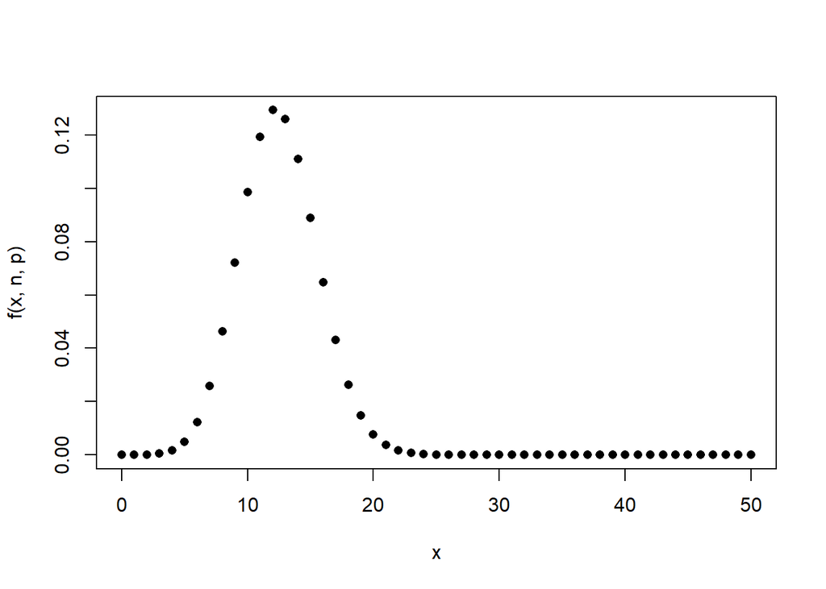

Figure 1: $51$ points demonstrating the shape of the binomial mass function for parameters $p = 0.25$ and $n = 50$.

```r
f = function(x, n, p){
   return( (p^x)*((1-p)^(n-x))*factorial(n)/(factorial(x)*factorial(n-x)))
}

n <- 50
p <- 0.25
x <- 0:n

plot(x, f(x, n, p), pch = 16)
```

Let’s try some different values of $p$. We can use the function `points()` to plot all of our graphs together.

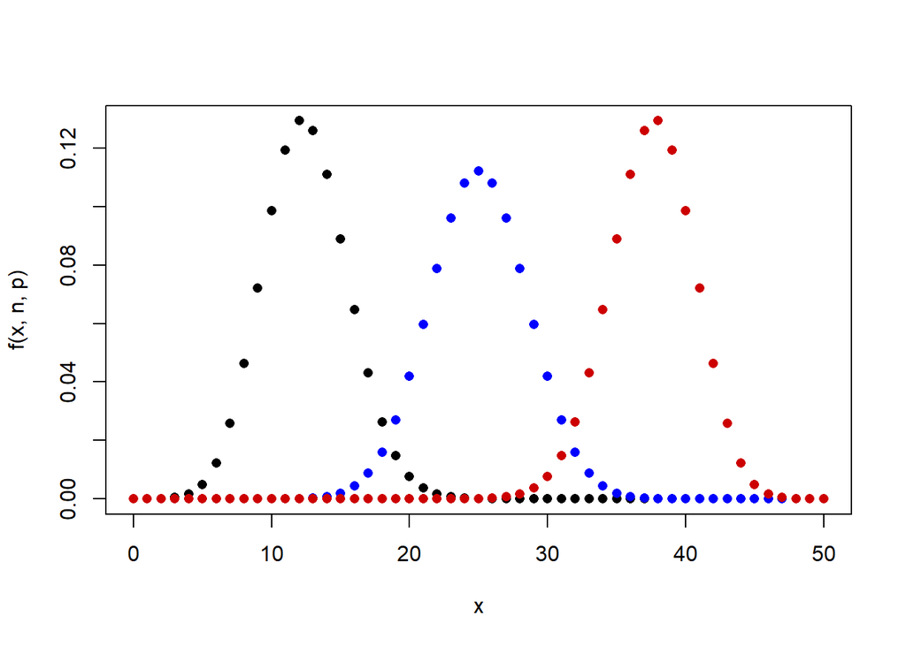

Figure 2: Plots of three different binomial mass functions, showing the effect that $p$ has on location and spread. As we saw in lectures, the mean for this distribution is $np$, so When $p$ is $0.5$ the centre of the distribution is at $25$. As $p$ gets higher or lower, the mean moves right or left (respectively). The spread also appears to decrease as $p$ gets further from $0.5$.

```r
plot(x, f(x, n, p), pch = 16)

points(x, f(x, n, p = 0.5), col = "blue", pch = 16)
points(x, f(x, n, p = 0.75), col = "red3", pch = 16)
```

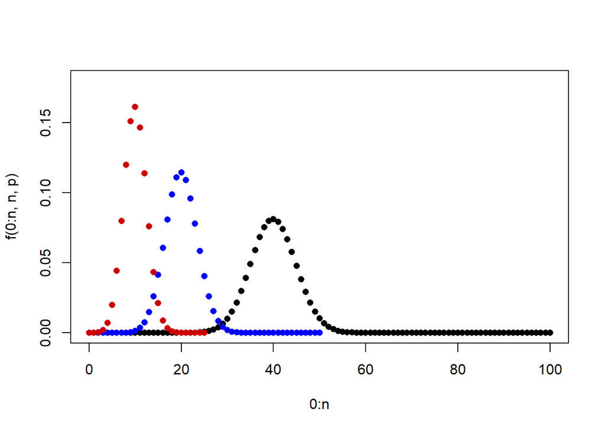

Figure 3: Plots of three different binomial mass functions, showing the effect that $n$ has on location and spread. It should be obvious that as $n$ decreases the range of possible values is smaller, and therefore the location and spread of the distribution become smaller. When $n$ is larger, the skew appears to decrease and the distribution appears to become more symmetrical.

```r
p <- 0.4

n <- 100
plot(0:n, f(0:n, n , p), pch = 16, ylim = c(0, 0.18))

n <- 50
points(0:n, f(0:n, n , p), col = "blue", pch = 16)

n <- 25
points(0:n, f(0:n, n , p), col = "red3", pch = 16)
```

## Solution to Exercise 2

There are three steps in the definition of this function: calculate all probabilities for values of $X$ up to $X = x$, add up these probabilities to get ${\mathsf P}(X \leq x)$, then return them. More efficiently,

```r
F <- function(x, n, p){ return(sum(f(0:x, n, p)) )}
```

## Solution to Exercise 3

Just plugging in a few values for `x` will be enough here, but we can also check for all possible values of `x` by creating a loop:

```r
p <- 0.25
n <- 10

# Compare cumulative probabilities at each x
# (our function on the left, R's on the right):

for(x in 0:10){

  print(paste("(", F(x, n, p), ", ", pbinom(x, size = n, prob = p), ")", sep = ""))
}
```

```
## [1] "(0.0563135147094727, 0.0563135147094727)"
## [1] "(0.244025230407715, 0.244025230407715)"
## [1] "(0.525592803955078, 0.525592803955078)"
## [1] "(0.775875091552734, 0.775875091552734)"
## [1] "(0.921873092651367, 0.921873092651367)"
## [1] "(0.98027229309082, 0.98027229309082)"
## [1] "(0.996494293212891, 0.996494293212891)"
## [1] "(0.999584197998047, 0.999584197998047)"
## [1] "(0.999970436096191, 0.999970436096191)"
## [1] "(0.999999046325684, 0.999999046325684)"
## [1] "(1, 1)"
```

```r
# Compare probability masses at each x
# (our function on the left, R's on the right):

for(x in 0:10){

  print(paste("(", f(x, n, p), ", ", dbinom(x, size = n, prob = p), ")", sep = ""))
}
```

```
## [1] "(0.0563135147094727, 0.0563135147094727)"
## [1] "(0.187711715698242, 0.187711715698242)"
## [1] "(0.281567573547363, 0.281567573547363)"
## [1] "(0.250282287597656, 0.250282287597656)"
## [1] "(0.145998001098633, 0.145998001098633)"
## [1] "(0.0583992004394531, 0.0583992004394531)"
## [1] "(0.0162220001220703, 0.0162220001220703)"
## [1] "(0.00308990478515625, 0.00308990478515625)"
## [1] "(0.000386238098144531, 0.000386238098144531)"
## [1] "(2.86102294921875e-05, 2.86102294921875e-05)"
## [1] "(9.5367431640625e-07, 9.5367431640625e-07)"
```

## Solution to Exercise 4

```r
x <- 0:10
p <- 0.25
n <- 10

sum(f(x, n, p))
```

```
## [1] 1
```

```r
E <- sum(x*f(x, n, p))
E
```

```
## [1] 2.5
```

```r
n*p
```

```
## [1] 2.5
```

We can similarly check that the variance is $np(1-p)$:

[output not shown]

## Solution to Exercise 5

The important difference here is that a Poisson distribution can take infinitely many values, and we can’t sum over all of them in R. At best, we can sum over “many” values and hope to see answers that are approximately correct.

```r
x <- 0:1000  # lots of possible values

sum(dpois(x, lambda = 2.5))
```

```
## [1] 1
```

```r
E <- sum(x*dpois(x, lambda = 2.5))
E
```

```
## [1] 2.5
```

```r
# And we can check that the variance is equal to lambda too:

var <- sum( (x - E)^2 * dpois(x, lambda = 2.5) )
var
```

```
## [1] 2.5
```

## Solution to Exercise 6

```r
# We can choose some values of a and b to check this:

a <- 8
b <- 3

# Notice that we don't need to include "mean =" or "sd = "
# as long as we put them in the correct order.

pnorm(a + b, 10, 5)
```

```
## [1] 0.5792597
```

```r
pnorm(a, 10, 5) + pnorm(b, 20, 10)
```

```
## [1] 0.3891437
```

## Solution to Exercise 7

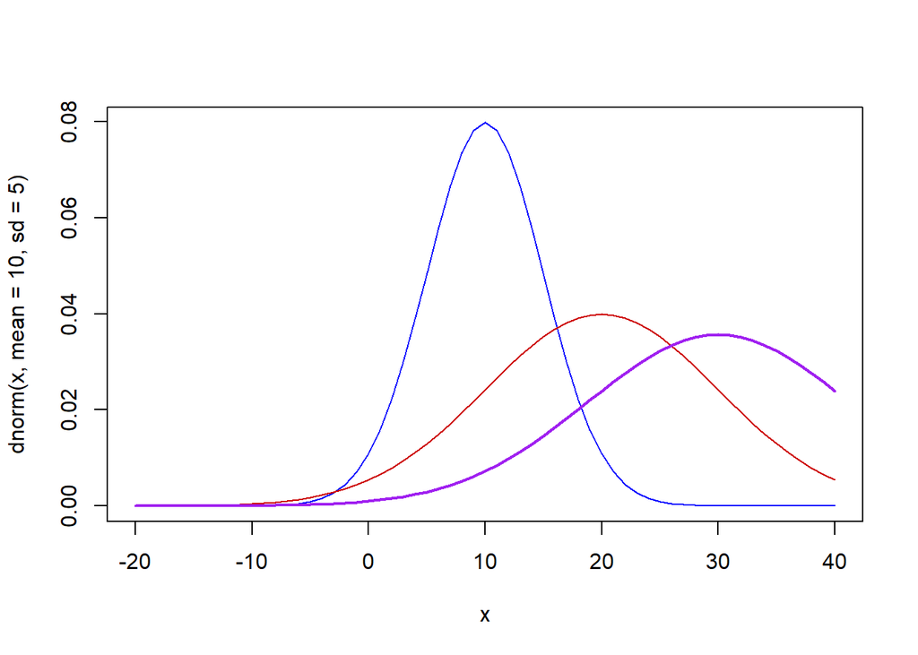

Figure 4: Normal density curves for $X$, $Y$ and $X + Y$. We can see that the curve for $X + Y$ has a greater spread (its variance is the sum of the variances for $X$ and $Y$) and its location is further to the right (its expectation is the sum of the expectations for $X$ and $Y$).

```r
x <- -20:40
y <- -20:40

plot(x, dnorm(x, mean = 10, sd = 5), type = "l", col = "blue")

lines(y, dnorm(y, mean = 20, sd = 10), type = "l", col = "red3")

# Now we plot the density of X + Y for the same values as X and Y:

lines(-20:40, dnorm(-20:40, mean = 10 + 20, sd = sqrt(5^2 + 10^2)), type = "l", col = "purple", lwd = 2)
```

In this graph, we see the normal density curves for $X$ and $Y$ to the left. We see the curve for $X + Y$ to the right with, as expected, a higher mean ($10 + 20$) and a higher spread (the variance should be $5^2 + 10^2$).

## Solution to Exercise 8

```r
x1 <- rnorm(n = 10000, 10, 5)
x2 <- rnorm(n = 10000, 20, 10)

mean(x1 + x2)
```

```
## [1] 30.07057
```

```r
sd(x1 + x2)^2
```

```
## [1] 123.6565
```

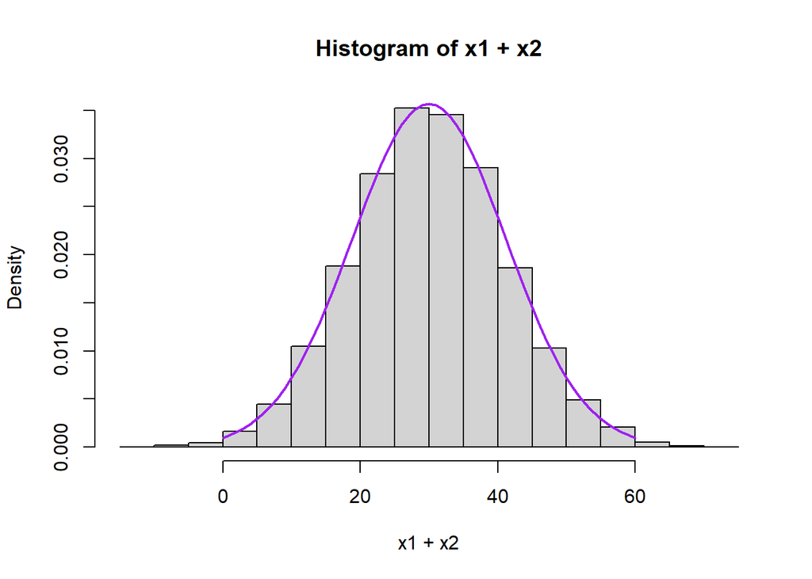

Figure 5: A histogram of our sampled values, showing a clear bell shape, similar to a normal distribution. A normal density curve based on the anticipated parameters is superimposed on the histogram, showing that they agree very closely, which seems to confirm normality of our sample.

```r
# To check the distribution, we can plot a histogram:

hist(x1 + x2, freq = FALSE)

# We can even add the curve from the previous question to
# see if our examples are consistent:

lines(0:60, dnorm(0:60, mean = 10 + 20, sd = sqrt(5^2 + 10^2)), type = "l", col = "purple", lwd = 2)
```